# The Geometry of Severe Malaria

A Vignette

David Smith

2022-05-27

Library | Primer | Epidemiology

**Lectures & Vignettes** Tracking Variables | Cronus

## .

We need to develop a model for severe malaria.

- **Introduction**
- The parasite **phenotype** model assumes severe malaria is a result of exposure to a *severe phenotype.*

## Intro

Severe malaria is the condition that includes most malaria mortality, so it is of great importance to understand the factors that contribute to its incidence. Here, we develop mathematical models severe malaria and its causes and incidence by age in a population, and we explore the geometry of the functional relationships between exposure intensity and incidence by age. We ask two questions:

- What malarial factors the total incidence of malaria summed over the age of a population?
- What non-malarial factors affect the incidence of severe malaria?

**References:**

- Trape, J.-F., Rogier, C., Konate, L., Diagne, N., Bouganali, H., Canque, B., Legros, F., Badji, A., Ndiaye, G., Ndiaye, P., et al. (1994). The Dielmo project: a longitudinal study of natural malaria infection and the mechanisms of protective immunity in a community living in a holoendemic area of Senegal. Am. J. Trop. Med. Hyg. 51, 123–137..
- Snow, R.W., Omumbo, J.A., Lowe, B., Molyneux, C.S., Obiero, J.O., Palmer, A., Weber, M.W., Pinder, M., Nahlen, B., Obonyo, C., et al. (1997). Relation between severe malaria morbidity in children and level of *Plasmodium falciparum* transmission in Africa. Lancet 349, 1650–1654.
- Rogier, C., Tall, A., Diagne, N., Fontenille, D., Spiegel, A., and Trape, J.F. (1999). Plasmodium falciparum clinical malaria: lessons from longitudinal studies in Senegal. Parassitologia 41, 255–259.
- Marsh, K., and Snow, R.W. (1999). Malaria transmission and morbidity. Parassitologia 41, 241.
- Gupta, S., Snow, R.W., Donnelly, C.A., Marsh, K., and Newbold, C. (1999). Immunity to non-cerebral severe malaria is acquired after one or two infections. Nat. Med. 5, 340–343..
- Reyburn, H., Mbatia, R., Drakeley, C.J., Bruce, J., Carneiro, I., Olomi, R., Cox, J., Nkya, W.M.M.M., Lemnge, M., Greenwood, B.M., et al. (2005). Association of transmission intensity and age with clinical manifestations and case fatality of severe *Plasmodium falciparum* malaria. Journal of the American Medical Assocation 293, 1461–1470.
- Okiro, E.A., Al-Taiar, A., Reyburn, H., Idro, R., Berkley, J.A., and Snow, R.W. (2009). Age patterns of severe paediatric malaria and their relationship to Plasmodium falciparum transmission intensity. Malar. J. 8, 4.
- Griffin, J.T., Ferguson, N.M., and Ghani, A.C. (2014). Estimates of the changing age-burden of *Plasmodium falciparum* malaria disease in sub-Saharan Africa. Nat. Commun. 5, 3136.
- Trape, J.-F., Tall, A., Sokhna, C., Ly, A.B., Diagne, N., Ndiath, O., Mazenot, C., Richard, V., Badiane, A., Dieye-Ba, F., et al. (2014). The rise and fall of malaria in a West African rural community, Dielmo, Senegal, from 1990 to 2012: a 22 year longitudinal study. Lancet Infect. Dis. 14, 476–488..
- Griffin, J.T., Hollingsworth, T.D., Reyburn, H., Drakeley, C.J., Riley, E.M., and Ghani, A.C. (2015). Gradual acquisition of immunity to severe malaria with increasing exposure. Proceedings of the Royal Society of London B: Biological Sciences 282, 20142657–20142657.
- Kamau, A., Paton, R.S., Akech, S., Mpimbaza, A., Khazenzi, C., Ogero, M., Mumo, E., Alegana, V.A., Agweyu, A., Mturi, N., et al. (2022). Malaria hospitalisation in East Africa: age, phenotype and transmission intensity. BMC Med. 20, 28..

## Phenotype

### .

**Outline**

- Exposure *vs.* age

### Age

One hypothesis is that severe malaria is caused by exposure to a *severe phenotype*. One possible way to formulate this model is the following. Suppose that there are $N$ phenotypes circulating.

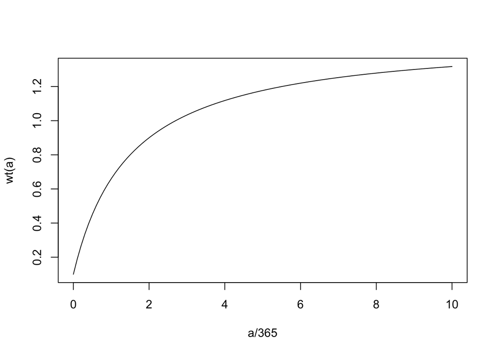

```r
wt = function(a){
  s = 1/15/365
  0.1 + 1.4*s*a/(0.1 + s*a)
}
a=seq(0,3650, length.out=100)
plot(a/365, wt(a), type = "l")
```

### Dynamics

- Let $N$ denote the number of *severe phenotypes*, and we let each phenotype cause a severe case with probability $T/N$.
  - There are $T$ total bad phenotypes.
  - In a model with no immune decay and no maternal protection, the total number of cases is at most $T$.
- Let $V$ denote a tracking variable with a decay rate.
  - The probability a phenotype has been seen recently is $e^{-V/N}$
- A parameter `Ve` modifies whether the model tracks EIR (`Ve=1`) or FoI (`Ve=0`).

```r
severeDE = function(a,y,p){with(as.list(c(y,p)),{
  foi = eir2foi(b*eir*wt(a), tau=10)
  M = M0*exp(-a/Mdk)
#  dV = (b*eir*Ve + (1-Ve)*foi)*exp(-M) - Vdk*V
  dV = (b*eir*Ve + (1-Ve)*foi) - Vdk*V
  dSevere = T/N*exp(-(V+M)/N)*foi
  list(c(dV, dSevere))
})}

severeSolve = function(eir, b=0.55, Ve=0, N=25, Md=10, Mdk=90, Vdk=0, Tot=1, Tmax=3650){
  tms = 0:Tmax
  foi = eir2foi(eir, tau=10)
  M0 = (b*eir*Ve + (1-Ve)*foi)*7300/Md
  prms = c(b=b, eir=eir, N=N, Ve=Ve, M0=M0, Mdk=Mdk, Vdk=Vdk, T=Tot)
  VM = data.frame(lsode(c(V=0,Severe=0), times=tms, severeDE, prms))
  return(VM)
}
```

```r
severeSolve(1/365) -> out
```

### Plots

#### .

```r
plotSevere = function(N, Ve=0, Vdk=0, Md=50){
  colors = turbo(6)
  deir = 3^c(0:5)/365
  vmc = list()
  for(i in 1:6) vmc[[i]]  = severeSolve(deir[i], N=N, Ve=Ve, Vdk=Vdk, Md=Md)

  ylm1 = range(diff(vmc[[1]]$Severe))
  for(i in 2:6) ylm1 = range(ylm1, diff(vmc[[i]]$Severe))

  ylm2 = range(c(0,1))
  for(i in 1:6) ylm2 = range(ylm2, vmc[[i]]$Severe)

  with(vmc[[i]], plot(time[-1]/365,  diff(Severe)*365, ylab = "Age (Years)", ylim = ylm1*365, type = "l", col = colors[1], main = paste("N=", N)))
  for(i in 2:6) with(vmc[[i]], lines(time[-1]/365, diff(Severe)*365, col = colors[i]))

  with(vmc[[i]], plot(time/365,  Severe, ylim = ylm2, ylab = "Age (Years)", type = "l", col = colors[1], main = paste("N=",N)))
  for(i in 2:6) with(vmc[[i]], lines(time/365, Severe, col = colors[i]))
}
```

#### Patterns

We start with a model without decay and with negligle effects of maternal protection.

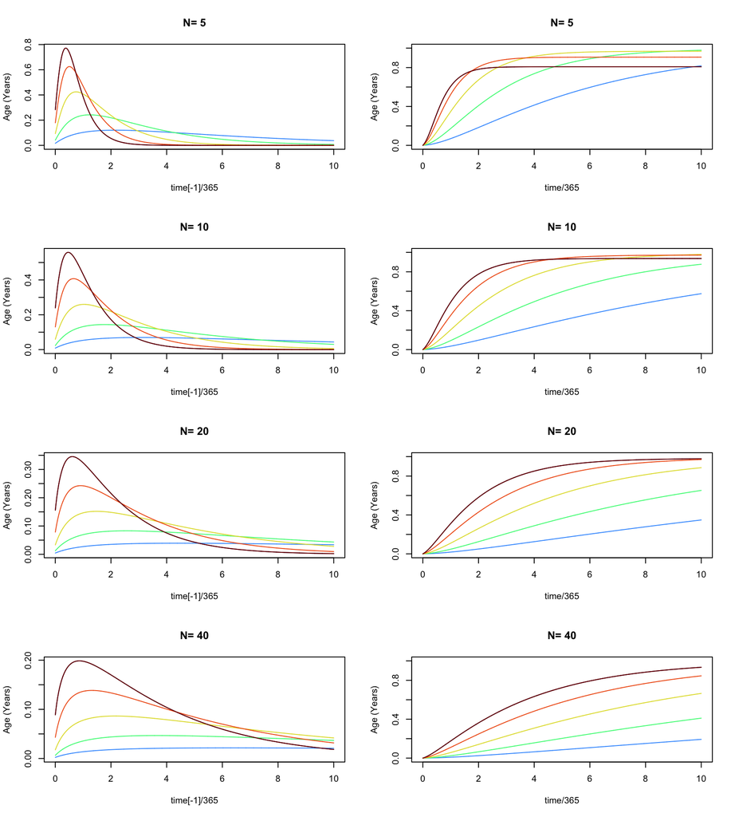

```r
lN = c(5,10,20,40)
par(mfrow = c(4,2))
for(i in 1:4) plotSevere(lN[i], Vdk=0)
```

#### Maternal

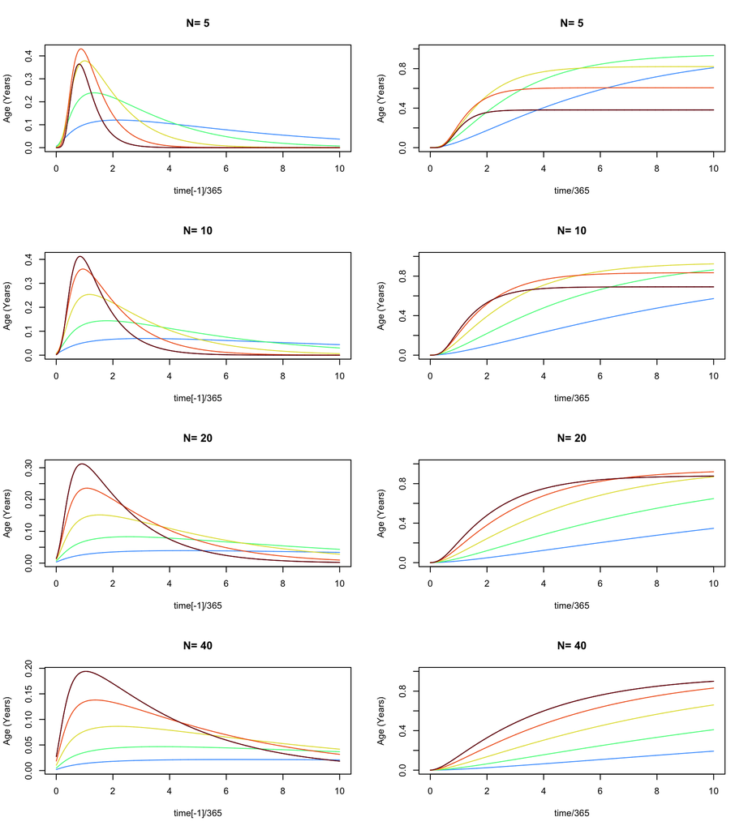

```r
lN = c(5,10,20,40)
par(mfrow = c(4,2))
for(i in 1:4) plotSevere(lN[i], Md=5)
```

#### Decay

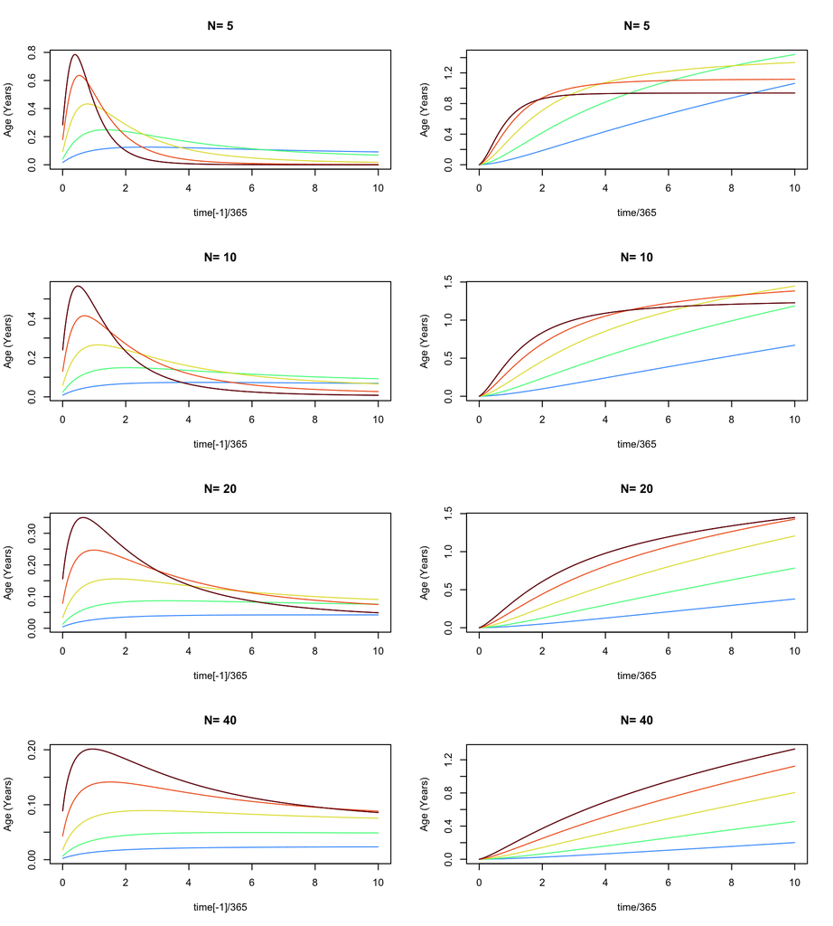

```r
lN = c(5,10,20,40)
par(mfrow = c(4,2))
for(i in 1:4) plotSevere(lN[i], Vdk=1/5/365)
```